# Low-Dose Naltrexone Across Two Patient Communities — Dosing and Tolerability

**Scope and an important caveat.** This notebook compares low-dose naltrexone (LDN) use in two independent online patient communities — **r/covidlonghaulers** (Long COVID; the cohort behind our FDA comment, n=321 LDN patients) and **Phoenix Rising** (a long-standing ME/CFS + Long COVID forum, n=354 LDN patients). It is restricted to the two measures that are **comparable** across the corpora:

1. **Reported dose** — mined by the *same regex over raw post text*, so it does not depend on how either corpus was classified.
2. **Reported side effects** — the structured side-effect field, categorized by one shared rule set.

> **Sentiment / response rate is intentionally excluded.** The two corpora were classified with different models and prompts and aggregated by different dedup rules; their headline positive rates (CLH 68.5% vs Phoenix ~36% user-level) are **not** comparable and must not be read as a benefit comparison. Nothing here pools or contrasts sentiment.

These are self-reported, uncontrolled data and do not establish efficacy or safety.

## 1. Real-world LDN dosing — both communities cluster ≤4.5 mg

Each bar is one **exact stated dose** (not binned); height = patients reporting that dose as their lowest, **stacked by source**. The shaded band is the ≤4.5 mg established-LDN range — the only FDA-approved naltrexone product is the 50 mg tablet.

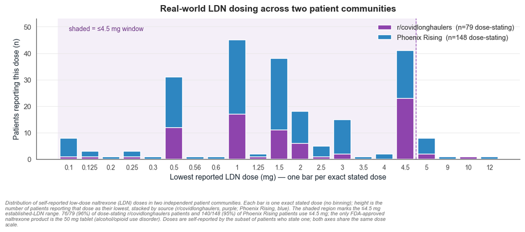

## 2. Reported side-effect counts — pooled, colored by source

One bar per side-effect category; length = number of side-effect reports mentioning it, **stacked by source**. Categories overlap (a report can mention several). Green labels mark the three effects the clinical literature names as characteristic of LDN.

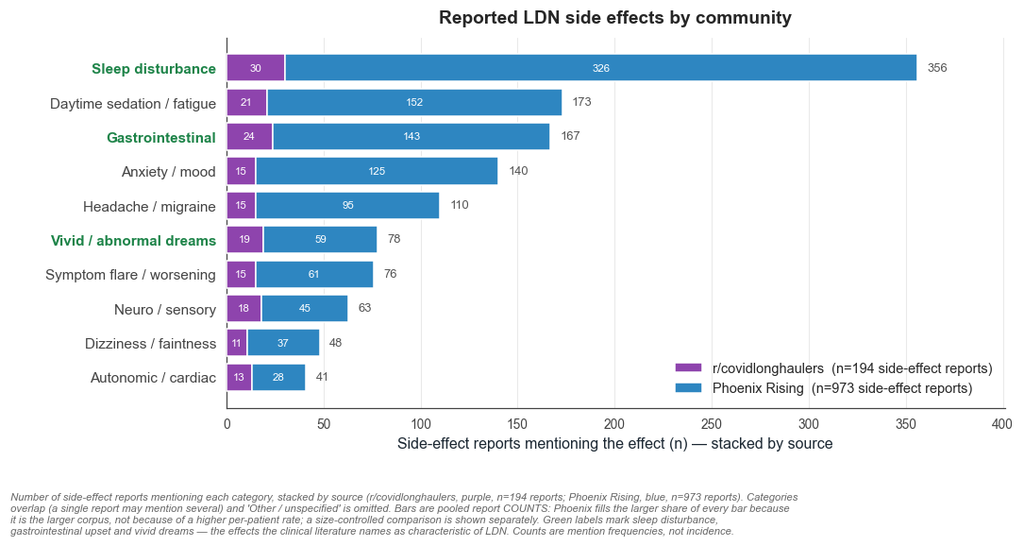

## 3. How the reported side effects compare to the clinical trials

Du & Nguyen (2025) pool the LDN trials and report six side effects as **% of trial patients**. The comparable real-world unit is the **% of LDN patients** in a cohort whose reports mention that effect. Two views follow: absolute magnitude (3a), then size-normalized profile shape (3b).

**3a. Magnitude — r/covidlonghaulers vs the trials.** Only the matched-method r/covidlonghaulers cohort is shown against the clinical magnitudes. Phoenix Rising is omitted *here*: its side-effect extraction was ~4× more liberal (60% vs 15% of reports carry a side-effect term), inflating its per-patient rates above clinical incidence — a prompt artifact, not a real difference. Phoenix appears in 3b on a size-normalized footing.

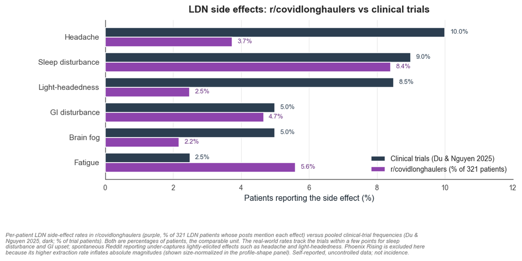

**3b. Profile shape — all three sources.** To place Phoenix Rising on the same footing despite its higher extraction rate, each source's six-category profile is scaled to 100% (relative emphasis, not incidence). The question becomes: *of the reported side effects, is the mix the same?*

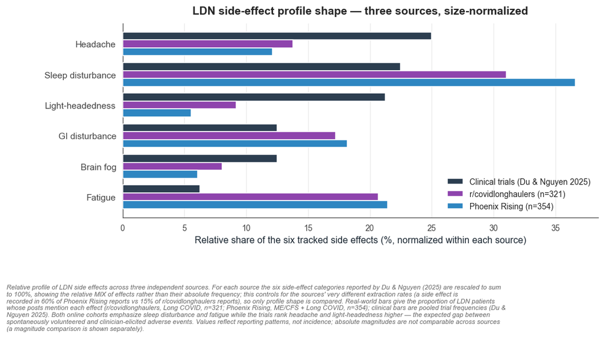

## 4. Does side-effect reporting track dose?

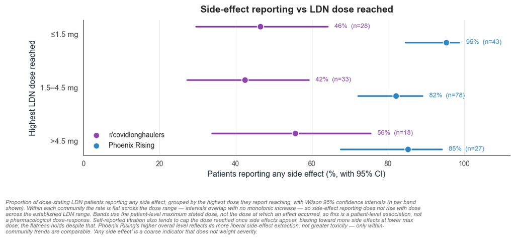

[figure not shown]

**4c. By individual side effect (Phoenix Rising).** Breaking the relationship out per side-effect category needs more data than r/covidlonghaulers can supply at this split — its category-by-dose cells are single-digit. Phoenix Rising can support it; denominators are all dose-stating patients per band, so within-cohort the trend is unaffected by Phoenix's higher overall reporting level.

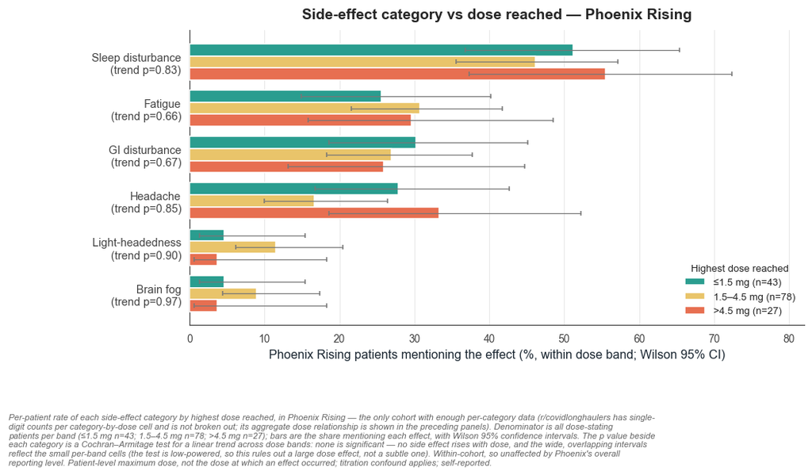

**4d. Both forums combined (cohort-adjusted).** Pooling the two communities for more power — but adjusted for their different baseline reporting rates so the extraction-rate gap cannot leak into the dose comparison. Bars are directly standardized rates (a fixed cohort mix applied across all bands, so band differences reflect dose, not composition); the p value is a Cochran–Armitage trend test **stratified by forum** (each forum's own baseline held constant, within-forum dose signals pooled). Error bars are approximate 95% CIs.

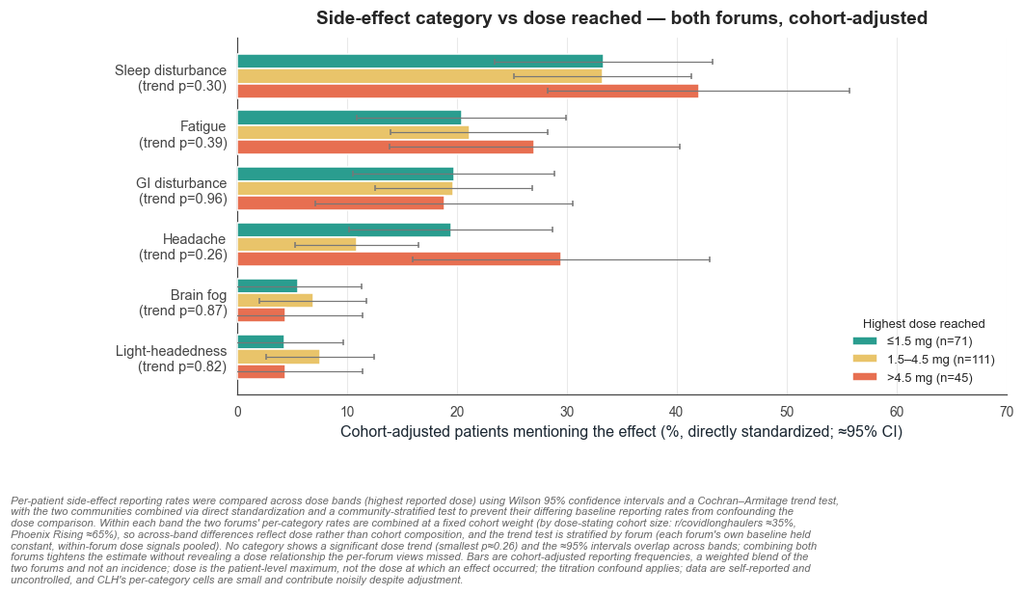

## 5. Tolerability headline numbers, per community

Side effects are common to mention but rarely described as limiting. Denominators differ, so these are shown **side by side, never pooled.**

| Measure | r/covidlonghaulers | Phoenix Rising |
| --- | --- | --- |
| Total LDN reports | 1316 | 1622 |
| Reports mentioning a side effect | 194 (14.7%) | 973 (60.0%) |
| Reports describing discontinuation | 26 (2.0%) | 125 (7.7%) |
| Reports with a serious-event term | 10 (0.8%) | 1 (0.1%) |

Discontinuation language is uncommon in both (2.0% CLH, 7.7% Phoenix), and structured serious-event terms are rare (10 CLH, 1 Phoenix). With no denominator of total users at risk this corroborates a benign tolerability profile; it cannot establish safety.

## What these data are — and are not

- **Sentiment is excluded by design.** The corpora were classified differently; only dose and side-effect *shape* are compared here.
- **Side-effect percentages are mention rates, not incidence.** Patients who tolerate LDN often say nothing; reactors post more; early quitters are under-counted. Extraction prompts also differed between corpora.
- **Dose rests on the minority who state one** (~25–40% of LDN patients) and is self-reported.
- **No control group, selection/survivorship bias, observational throughout.** These data show real-world dosing and tolerability patterns across two communities; they do not establish efficacy or safety. Only a randomized, actively-monitored trial can.

These findings reflect reporting patterns in online communities, not population-level treatment effects. This is not medical advice.